# 2 Subsetting

Lucas Shen

August 10, 2015

> `str()` shows you the structure of any object, and **subsetting** allows you to pull out the pieces that you’re interested in.

## Data types

### 1. Atomic vectors

```r
x <- c(2.1, 4.2, 3.3, 5.4) # number after the decimal point gives the original position in the vector
```

#### things you can use to subset a vector:

1. **positive integer** (what you want)

```r
x[c(3,1)]
```

```
## [1] 3.3 2.1
```

```r
x[order(x)] # order return sorted index, this line == sort(x)
```

```
## [1] 2.1 3.3 4.2 5.4
```

```r
x[c(1,1)] # return duplicate values
```

```
## [1] 2.1 2.1
```

2. **negative integer** (what you don’t want)

```r
x[-1]
```

```
## [1] 4.2 3.3 5.4
```

3. **logical vector**

```r
x[c(TRUE, TRUE, FALSE, FALSE)]
```

```
## [1] 2.1 4.2
```

```r
x[x>3]
```

```
## [1] 4.2 3.3 5.4
```

if logical vector is shorter than input vector, it will recycle to be the same length

```r
x[c(TRUE, FALSE)]
```

```
## [1] 2.1 3.3
```

4. **nothing**, `x[]`: return original vector
5. **zero**, `x[0]`: return zero-length vector
6. **character vectors**, return elements with matching names

```r
y <- setNames(x, letters[1:4])
y[c("d", "c", "a")]
```

```
##   d   c   a
## 5.4 3.3 2.1
```

### 2. Matrices and arrays

```r
a <- matrix(1:9, nrow=3)
colnames(a) <- c('A', 'B', 'C')

a[1:2, ] # keep all colums
```

```
##      A B C
## [1,] 1 4 7
## [2,] 2 5 8
```

### 3. Data frames

> list of columns

```r
df <- data.frame(x=1:3, y=3:1, z=letters[1:3])
df[df$x ==2,] # take 2nd row
```

```
##   x y z
## 2 2 2 b
```

```r
df[c(1,3), ] # take 1, 3 row
```

```
##   x y z
## 1 1 3 a
## 3 3 1 c
```

```r
df[c('x', 'z')] # == df[, c('x', 'z')]
```

```
##   x z
## 1 1 a
## 2 2 b
## 3 3 c
```

if only choose one colume,

```r
str(df['x']) # this subsetting would not simplify automatically
```

```
## 'data.frame':    3 obs. of  1 variable:
##  $ x: int  1 2 3
```

```r
str(df[, 'x']) # auto simplify
```

```
##  int [1:3] 1 2 3
```

notes inspired from exercise:

- `upper.tri()`
- `diag()`

> Implement your own function that extracts the diagonal entries from a matrix (it should behave like diag(x) where x is a matrix).

```r
my_diag <- function(m){
  count <- min(ncol(m), nrow(m))
  if (count>1){
    res <- c()
    for (i in 1:count){
      res <- c(res, m[i,i])
    }
    res
  }
}
```

```r
a
```

```
##      A B C
## [1,] 1 4 7
## [2,] 2 5 8
## [3,] 3 6 9
```

```r
my_diag(a)
```

```
## A B C
## 1 5 9
```

# todo: I don’t like this version, redo!

## Subsetting operators

1. `[[`, return single value
2. `$`, often used to access variables in a data frame, as in mtcars$cyl or diamonds$carat.

> If list x is a train carrying objects, then `x[[5]]` is the object in car 5; `x[4:6]` is a train of cars 4-6.

```r
a <- list(a=1, b=2)
a[[1]]
```

```
## [1] 1
```

```r
a[['a']]
```

```
## [1] 1
```

In this named list case, you can see the difference:

```r
typeof(a[1]) # this is still a list, you could use a[1][[1]] to get a[[1]] value
```

```
## [1] "list"
```

```r
typeof(a[[1]]) # this would be "that" value you want
```

```
## [1] "double"
```

about `$`

```r
mtcars$cyl
```

```
##  [1] 6 6 4 6 8 6 8 4 4 6 6 8 8 8 8 8 8 4 4 4 4 8 8 8 8 4 4 4 8 6 8 4
```

```r
mtcars[['cyl']]
```

```
##  [1] 6 6 4 6 8 6 8 4 4 6 6 8 8 8 8 8 8 4 4 4 4 8 8 8 8 4 4 4 8 6 8 4
```

There’s one important difference between $ and [[. `$` does partial matching

### Simplifying vs preseving

> **Simplifying** subsets returns the simplest possible data structure that can represent the output, and is useful interactively because it usually gives you what you want.

> **Preserving** subsetting keeps the structure of the output the same as the input, and is generally better for programming because the result will always be the same type.

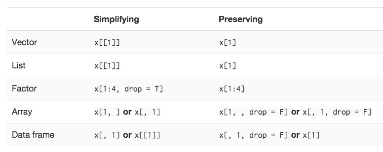

### Modify subset

```r
x <- 1:5
x[1:3] <- 6:8
x
```

```
## [1] 6 7 8 4 5
```

> Subsetting with nothing can be useful in conjunction with assignment because it will preserve the original object class and structure.

```r
mtcars[] <- lapply(mtcars, as.integer) # still a data frame
mtcars <- lapply(mtcars, as.integer) # list
```

**Todo: skipped application part. To much for now, pick up later**

#### exercise:

1. > randomly permute the columns of a data frame?

```r
df
```

```
##   x y z
## 1 1 3 a
## 2 2 2 b
## 3 3 1 c
```

```r
df2 <- df[sample(nrow(df)), sample(ncol(df))] # row and col same time
df2
```

```
##   x z y
## 2 2 b 2
## 3 3 c 1
## 1 1 a 3
```

```r
df2 <- df[sample(nrow(df)), ] # suffle only rows, you know how to do only cols
df2
```

```
##   x y z
## 3 3 1 c
## 1 1 3 a
## 2 2 2 b
```

2. > put the columns in a data frame in alphabetical order?

```r
str(mtcars[order(names(mtcars))])
```

```
## List of 11
##  $ am  : int [1:32] 1 1 1 0 0 0 0 0 0 0 ...
##  $ carb: int [1:32] 4 4 1 1 2 1 4 2 2 4 ...
##  $ cyl : int [1:32] 6 6 4 6 8 6 8 4 4 6 ...
##  $ disp: int [1:32] 160 160 108 258 360 225 360 146 140 167 ...
##  $ drat: int [1:32] 3 3 3 3 3 2 3 3 3 3 ...
##  $ gear: int [1:32] 4 4 4 3 3 3 3 4 4 4 ...
##  $ hp  : int [1:32] 110 110 93 110 175 105 245 62 95 123 ...
##  $ mpg : int [1:32] 21 21 22 21 18 18 14 24 22 19 ...
##  $ qsec: int [1:32] 16 17 18 19 17 20 15 20 22 18 ...
##  $ vs  : int [1:32] 0 0 1 1 0 1 0 1 1 1 ...
##  $ wt  : int [1:32] 2 2 2 3 3 3 3 3 3 3 ...
```